## Module 1: Data Collection

# Collecting Data Using APIs

```python
from IPython.core.display import display, HTML
display(HTML("<style>.container { width:90% !important; }</style>"))
```

```python
import requests
import os
from PIL import Image
from IPython.display import IFrame
import pandas as pd
import json
import numpy as np
import seaborn as sns
import matplotlib.pyplot as plt

from bs4 import BeautifulSoup # this module helps in web scrapping.
import requests  # this module helps us to download a web page
```

```python
url='https://www.ibm.com/'
r=requests.get(url)
```

### Resquest

```python
# the status of the request
r.status_code
```

```
200
```

```python
# view the request headers
r.request.headers
```

```
{'User-Agent': 'python-requests/2.28.1', 'Accept-Encoding': 'gzip, deflate', 'Accept': '*/*', 'Connection': 'keep-alive', 'Cookie': '_abck=000D7EA7D7226CDF1765622CD2AC1930~-1~YAAQCW4sF0LEcTeKAQAAmBikOApQl6zj/G3FD9K7kO+BqT1Dz+/NwDzEfFNX…=~-1~-1~-1; bm_sz=A4640AAB85E461EC3B0C237E9F551D69~YAAQCW4sF0PEc…
```

### Response

#### Text

```python
#  view the HTTP response header
header=r.headers
print(r.headers)
```

```
{'Accept-Ranges': 'bytes', 'Content-Type': 'text/html', 'ETag': '"81cf3b5dda132f3aeeaf7cf74c998296:1692916622.064576"', 'Last-Modified': 'Thu, 24 Aug 2023 18:38:39 GMT', 'Server': 'AkamaiNetStorage', 'Cache-Control': 'max-age=303', 'Expires': 'Sun, 27 Aug 2023 20:21:35 GMT', 'X-Akamai-Transformed': …
```

```python
# obtain the date the request was sent
header['date']
```

```
'Sun, 27 Aug 2023 20:16:32 GMT'
```

```python
# Content-Type indicates the type of data
header['Content-Type']
```

```
'text/html'
```

```python
r.text[0:100]
```

```
'<!DOCTYPE html><html lang="en-US"><head><meta name="viewport" content="width=device-width"/><meta ch'
```

#### Image

```python
# Use single quotation marks for defining string
url='https://cf-courses-data.s3.us.cloud-object-storage.appdomain.cloud/IBM-DA0321EN-SkillsNetwork/labs/module%201/images/IDSNlogo.png'

r=requests.get(url)
r.headers['Content-Type']
```

```
'image/png'
```

[figure not shown]

```python
path=os.path.join(os.getcwd(),'image.png')
with open(path,'wb') as f:
    f.write(r.content)

# view the image:
Image.open(path)
```

#### JSON

```python
# You can use the GET method  to  modify the results of your query
url_get='http://httpbin.org/get'
payload={"name":"Joseph","ID":"123"}
r=requests.get(url_get,params=payload)
r.url
```

```
'http://httpbin.org/get?name=Joseph&ID=123'
```

```python
r.headers['Content-Type']
```

```
'application/json'
```

```python
r.json()
```

```
{'args': {'ID': '123', 'name': 'Joseph'},
 'headers': {'Accept': '*/*',
  'Accept-Encoding': 'gzip, deflate',
  'Host': 'httpbin.org',
  'User-Agent': 'python-requests/2.28.1',
  'X-Amzn-Trace-Id': 'Root=1-64ebaf23-22536565710040f83586776f'},
 'origin': '71.105.236.170',
 'url': 'http://httpbin.org/get?name=Joseph&ID=123'}
```

### Post Requests

Like a `GET` request a `POST` is used to send data to a server, but the `POST` request sends the data in a request body.

```python
url_post='http://httpbin.org/post'
r_post=requests.post(url_post,data=payload)

r_post.json()['form']
```

```
{'ID': '123', 'name': 'Joseph'}
```

Comparing the URL from the response object of the `GET` and `POST` request we see the `POST` request has no name or value pairs.

```python
print("POST request URL:",r_post.url )
print("GET request URL:",r.url)
```

```
POST request URL: http://httpbin.org/post
GET request URL: http://httpbin.org/get?name=Joseph&ID=123
```

Comparing the `POST` and `GET` request bodies, we see only the `POST` request has a body:

```python
print("POST request body:",r_post.request.body)
print("GET request body:",r.request.body)
```

```
POST request body: name=Joseph&ID=123
GET request body: None
```

## Exercise: People on the International Space Station (ISS)

The API at http://api.open-notify.org/astros.json has information on astronauts currently on the ISS in json format.  
You can read more about this API at http://open-notify.org/Open-Notify-API/People-In-Space/

```python
api_url = "http://api.open-notify.org/astros.json"
response = requests.get(api_url)
if response.ok:             # if all is well(no errors, no network timeouts)
    data = response.json()  # store the result in json format in a variable called data

print(data)   # print the data just to check the output or for debugging
```

```
{'number': 10, 'people': [{'name': 'Sergey Prokopyev', 'craft': 'ISS'}, {'name': 'Dmitry Petelin', 'craft': 'ISS'}, {'name': 'Frank Rubio', 'craft': 'ISS'}, {'name': 'Stephen Bowen', 'craft': 'ISS'}, {'name': 'Warren Hoburg', 'craft': 'ISS'}, {'name': 'Sultan Alneyadi', 'craft': 'ISS'}, {'name': 'An…
```

The number of astronauts currently on ISS

```python
print(data.get('number'))
```

```
10
```

The names of each astronaut

```python
astronauts = data.get('people')
print("There are {} astronauts on ISS".format(len(astronauts)))
print("And their names are :")
for astronaut in astronauts:
    print(astronaut.get('name'))
```

```
There are 10 astronauts on ISS
And their names are :
Sergey Prokopyev
Dmitry Petelin
Frank Rubio
Stephen Bowen
Warren Hoburg
Sultan Alneyadi
Andrey Fedyaev
Jing Haiping
Gui Haichow
Zhu Yangzhu
```

## Exercise: Number of jobs currently open

Set up the data source for retrieval via API

##### The keys in the json are

- Job Title
- Job Experience Required
- Key Skills
- Role Category
- Location
- Functional Area
- Industry
- Role

How many job postings exist for the Python programming language?

```python
api_url="http://127.0.0.1:5000/data"
def get_number_of_jobs_T(technology):
    payload = {"Key Skills":technology}
    response = requests.get(api_url,params=payload)
    if response.ok:
        data = response.json()
    number_of_jobs = len(data)
    return technology,number_of_jobs

get_number_of_jobs_T("Python")
```

```
('Python', 1173)
```

How many job postings are there for the following locations:

```python
# How many job postings exist for each location?
def get_number_of_jobs_L(location):
    api_url_get = api_url + '/get'
    payload = {"Location":location}
    response = requests.get(api_url,params=payload)
    if response.ok:
        data = response.json()
    number_of_jobs = len(data)
    return location,number_of_jobs

L = ['Los Angeles', 'New York', 'San Francisco', 'Washington DC', 'Seattle']
for i in L:
    posting_count = get_number_of_jobs_L(i)
    print(posting_count)
```

```
('Los Angeles', 640)
('New York', 3226)
('San Francisco', 435)
('Washington DC', 5316)
('Seattle', 3375)
```

# Collecting Data Using Webscraping

```python
url = "http://www.ibm.com"

# get the contents of the webpage in text format and store in a variable called data
data  = requests.get(url).text

soup = BeautifulSoup(data,"html5lib")  # create a soup object using the variable 'data' and the class BeautifulSoup
```

Scrape all links

```python
for link in soup.find_all('a'):  # in html anchor/link is represented by the tag <a>
    print(link.get('href'))
```

```
https://www.ibm.com/thought-leadership/institute-business-value/en-us/report/ceo-generative-ai/application-modernization/
https://www.ibm.com/community/ibm-techxchange-conference
https://www.ibm.com/products/watsonx-ai
https://www.ibm.com/products/watsonx-data
https://www.ibm.com/products/spss-statistics/pricing
https://www.ibm.com/sports/usopen
https://www.ibm.com/cloud?lnk=flatitem
https://www.ibm.com/products
https://www.ibm.com/consulting
https://www.ibm.com/about
https://www.ibm.com/
```

Scrape all images

```python
for link in soup.find_all('img'):# in html image is represented by the tag <img>
    print(link.get('src'))
```

```
https://1.dam.s81c.com/p/0c627169442d5243/ibm_watsonx_data_closeup_still_4k.jpg.global.sr_1x1.jpg
https://1.dam.s81c.com/p/0c3ce2dfcccd1f24/watsonx-data-square.jpg
https://1.dam.s81c.com/p/0c3ce2dfcccd1f25/watsonx-ai-square.jpg
https://1.dam.s81c.com/p/0b5258b292cc8c3c/ibm-SPSS-home-card.png.global.xs_1x1.png
https://1.dam.s81c.com/p/0c9c5faa18c5c7c0/0c6278d221ada9b-1230810_ibm_us_open_2023_leadspace.jpg
https://1.dam.s81c.com/p/0aac9cf57bcbf324/dotcom-1-overview.jpg
```

Scrape data from html tables

```python
# The below url contains a html table with data about colors and color codes.
url = "https://cf-courses-data.s3.us.cloud-object-storage.appdomain.cloud/IBM-DA0321EN-SkillsNetwork/labs/datasets/HTMLColorCodes.html"

# get the contents of the webpage in text format and store in a variable called data
data  = requests.get(url).text

soup = BeautifulSoup(data,"html5lib")

#find a html table in the web page
table = soup.find('table') # in html table is represented by the tag <table>

#Get all rows from the table
for row in table.find_all('tr'): # in html table row is represented by the tag <tr>
    # Get all columns in each row.
    cols = row.find_all('td') # in html a column is represented by the tag <td>
    color_name = cols[2].getText() # store the value in column 3 as color_name
    color_code = cols[3].getText() # store the value in column 4 as color_code
    print("{}--->{}".format(color_name,color_code))
```

```
Color Name--->Hex Code#RRGGBB
lightsalmon--->#FFA07A
salmon--->#FA8072
darksalmon--->#E9967A
lightcoral--->#F08080
coral--->#FF7F50
tomato--->#FF6347
orangered--->#FF4500
gold--->#FFD700
orange--->#FFA500
darkorange--->#FF8C00
lightyellow--->#FFFFE0
lemonchiffon--->#FFFACD
papayawhip--->#FFEFD5
moccasin--->#FFE4B5
peachpuff--->#FFDAB9
palegoldenrod--->#EEE8AA
khaki--->#F0E68C
darkkhaki--->#BDB76B
yellow--->#FFFF00
lawngreen--->#7CFC00
chartreuse--->#7FFF00
limegreen--->#32CD32
lime--->#00FF00
forestgreen--->#228B22
green--->#008000
powderblue--->#B0E0E6
lightblue--->#ADD8E6
lightskyblue--->#87CEFA
skyblue--->#87CEEB
deepskyblue--->#00BFFF
lightsteelblue--->#B0C4DE
dodgerblue--->#1E90FF
```

## Module 2: Data Wrangling

### About the dataset

Stack Overflow, a popular website for developers, conducted an online survey of software professionals across the world. The survey data was later open sourced by Stack Overflow. The actual data set has around 90,000 responses.

The dataset you are going to use in this assignment comes from the following source: https://stackoverflow.blog/2019/04/09/the-2019-stack-overflow-developer-survey-results-are-in/ under a **ODbL: Open Database License**.

You will be given a subset of the original data set in this capstone project. You will explore, analyze, and visualize this dataset and present your analysis.

Note: This randomised subset contains around 1/10th of the original data set. Any conclusions you draw after analyzing this subset may not reflect the real world scenario.

The dataset is available as a .csv file [here](https://cf-courses-data.s3.us.cloud-object-storage.appdomain.cloud/IBM-DA0321EN-SkillsNetwork/LargeData/m1_survey_data.csv).

The below table lists the questions asked in the survey and the column under which the response was collected.

| Column Name | Question Text |
| --- | --- |
| Respondent | Randomized respondent ID number (not in order of survey response time) |
| MainBranch | Which of the following options best describes you today? Here, by “developer” we mean “someone who writes code.” |
| Hobbyist | Do you code as a hobby? |
| OpenSourcer | How often do you contribute to open source? |
| OpenSource | How do you feel about the quality of open source software (OSS)? |
| Employment | Which of the following best describes your current employment status? |
| Country | In which country do you currently reside? |
| Student | Are you currently enrolled in a formal, degree-granting college or university program? |
| EdLevel | Which of the following best describes the highest level of formal education that you’ve completed? |
| UndergradMajor | What was your main or most important field of study? |
| EduOther | Which of the following types of non-degree education have you used or participated in? Please select all that apply. |
| OrgSize | Approximately how many people are employed by the company or organization you work for? |
| DevType | Which of the following describe you? Please select all that apply. |
| YearsCode | Including any education, how many years have you been coding? |
| Age1stCode | At what age did you write your first line of code or program? (E.g., webpage, Hello World, Scratch project) |
| YearsCodePro | How many years have you coded professionally (as a part of your work)? |
| CareerSat | Overall, how satisfied are you with your career thus far? |
| JobSat | How satisfied are you with your current job? (If you work multiple jobs, answer for the one you spend the most hours on.) |
| MgrIdiot | How confident are you that your manager knows what they’re doing? |
| MgrMoney | Do you believe that you need to be a manager to make more money? |
| MgrWant | Do you want to become a manager yourself in the future? |
| JobSeek | Which of the following best describes your current job-seeking status? |
| LastHireDate | When was the last time that you took a job with a new employer? |
| LastInt | In your most recent successful job interview (resulting in a job offer), you were asked to… (check all that apply) |
| FizzBuzz | Have you ever been asked to solve FizzBuzz in an interview? |
| JobFactors | Imagine that you are deciding between two job offers with the same compensation, benefits, and location. Of the following factors, which 3 are MOST important to you? |
| ResumeUpdate | Think back to the last time you updated your resumé, CV, or an online profile on a job site. What is the PRIMARY reason that you did so? |
| CurrencySymbol | Which currency do you use day-to-day? If your answer is complicated, please pick the one you’re most comfortable estimating in. |
| CurrencyDesc | Which currency do you use day-to-day? If your answer is complicated, please pick the one you’re most comfortable estimating in. |
| CompTotal | What is your current total compensation (salary, bonuses, and perks, before taxes and deductions), in `CurrencySymbol`? Please enter a whole number in the box below, without any punctuation. If you ar… |

[output cut: 55 more lines]

```python
dataset_url = "https://cf-courses-data.s3.us.cloud-object-storage.appdomain.cloud/IBM-DA0321EN-SkillsNetwork/LargeData/m1_survey_data.csv"

df = pd.read_csv(dataset_url)
df.head()
```

|  | Respondent | MainBranch | Hobbyist | OpenSourcer | OpenSource | Employment | Country | Student | EdLevel | UndergradMajor | ... | WelcomeChange | SONewContent | Age | Gender | Trans | Sexuality | Ethnicity | Dependents | SurveyLength | SurveyEase |
| --- | --- | --- | --- | --- | --- | --- | --- | --- | --- | --- | --- | --- | --- | --- | --- | --- | --- | --- | --- | --- | --- |
| 0 | 4 | I am a developer by profession | No | Never | The quality of OSS and closed source software ... | Employed full-time | United States | No | Bachelor’s degree (BA, BS, B.Eng., etc.) | Computer science, computer engineering, or sof... | ... | Just as welcome now as I felt last year | Tech articles written by other developers;Indu... | 22.0 | Man | No | Straight / Heterosexual | White or of European descent | No | Appropriate in length | Easy |
| 1 | 9 | I am a developer by profession | Yes | Once a month or more often | The quality of OSS and closed source software ... | Employed full-time | New Zealand | No | Some college/university study without earning ... | Computer science, computer engineering, or sof... | ... | Just as welcome now as I felt last year | NaN | 23.0 | Man | No | Bisexual | White or of European descent | No | Appropriate in length | Neither easy nor difficult |
| 2 | 13 | I am a developer by profession | Yes | Less than once a month but more than once per ... | OSS is, on average, of HIGHER quality than pro... | Employed full-time | United States | No | Master’s degree (MA, MS, M.Eng., MBA, etc.) | Computer science, computer engineering, or sof... | ... | Somewhat more welcome now than last year | Tech articles written by other developers;Cour... | 28.0 | Man | No | Straight / Heterosexual | White or of European descent | Yes | Appropriate in length | Easy |
| 3 | 16 | I am a developer by profession | Yes | Never | The quality of OSS and closed source software ... | Employed full-time | United Kingdom | No | Master’s degree (MA, MS, M.Eng., MBA, etc.) | NaN | ... | Just as welcome now as I felt last year | Tech articles written by other developers;Indu... | 26.0 | Man | No | Straight / Heterosexual | White or of European descent | No | Appropriate in length | Neither easy nor difficult |
| 4 | 17 | I am a developer by profession | Yes | Less than once a month but more than once per ... | The quality of OSS and closed source software ... | Employed full-time | Australia | No | Bachelor’s degree (BA, BS, B.Eng., etc.) | Computer science, computer engineering, or sof... | ... | Just as welcome now as I felt last year | Tech articles written by other developers;Indu... | 29.0 | Man | No | Straight / Heterosexual | Hispanic or Latino/Latina;Multiracial | No | Appropriate in length | Easy |

5 rows × 85 columns

# Finding Duplicates

```python
# occurrence based on all columns
df[df.duplicated()]#.head()
```

|  | Respondent | MainBranch | Hobbyist | OpenSourcer | OpenSource | Employment | Country | Student | EdLevel | UndergradMajor | ... | WelcomeChange | SONewContent | Age | Gender | Trans | Sexuality | Ethnicity | Dependents | SurveyLength | SurveyEase |
| --- | --- | --- | --- | --- | --- | --- | --- | --- | --- | --- | --- | --- | --- | --- | --- | --- | --- | --- | --- | --- | --- |
| 1168 | 2339 | I am a developer by profession | Yes | Once a month or more often | OSS is, on average, of HIGHER quality than pro... | Employed full-time | United States | No | Some college/university study without earning ... | Computer science, computer engineering, or sof... | ... | Just as welcome now as I felt last year | NaN | 24.0 | Man | No | Straight / Heterosexual | White or of European descent | No | Appropriate in length | Easy |
| 1169 | 2342 | I am a developer by profession | Yes | Never | The quality of OSS and closed source software ... | Employed full-time | United Kingdom | No | Some college/university study without earning ... | Information systems, information technology, o... | ... | Somewhat more welcome now than last year | Tech meetups or events in your area;Courses on... | 24.0 | Man | No | Straight / Heterosexual | White or of European descent | No | Too long | Easy |
| 1170 | 2343 | I am a developer by profession | Yes | Less than once a month but more than once per ... | OSS is, on average, of LOWER quality than prop... | Employed full-time | Canada | No | Master’s degree (MA, MS, M.Eng., MBA, etc.) | Computer science, computer engineering, or sof... | ... | Somewhat more welcome now than last year | Tech articles written by other developers;Indu... | 27.0 | Man | No | Straight / Heterosexual | Black or of African descent;White or of Europe... | No | Appropriate in length | Neither easy nor difficult |
| 1171 | 2344 | I am a developer by profession | Yes | Never | The quality of OSS and closed source software ... | Employed full-time | United States | No | Bachelor’s degree (BA, BS, B.Eng., etc.) | Computer science, computer engineering, or sof... | ... | Just as welcome now as I felt last year | Tech articles written by other developers;Indu... | 24.0 | Man | No | Straight / Heterosexual | White or of European descent | No | Appropriate in length | Easy |
| 1172 | 2347 | I am a developer by profession | Yes | Never | OSS is, on average, of HIGHER quality than pro... | Employed full-time | United Kingdom | No | Master’s degree (MA, MS, M.Eng., MBA, etc.) | Computer science, computer engineering, or sof... | ... | Just as welcome now as I felt last year | NaN | NaN | Woman | No | Straight / Heterosexual | Biracial | No | Too long | Easy |
| ... | ... | ... | ... | ... | ... | ... | ... | ... | ... | ... | ... | ... | ... | ... | ... | ... | ... | ... | ... | ... | ... |
| 2297 | 4674 | I am not primarily a developer, but I write co... | Yes | Less than once per year | The quality of OSS and closed source software ... | Employed full-time | Bangladesh | No | Bachelor’s degree (BA, BS, B.Eng., etc.) | NaN | ... | Somewhat less welcome now than last year | Tech articles written by other developers;Indu... | 31.0 | Man | No | Bisexual;Gay or Lesbian;Straight / Heterosexual | Black or of African descent;Hispanic or Latino... | Yes | Too long | Neither easy nor difficult |
| 2298 | 4675 | I am a developer by profession | Yes | Never | OSS is, on average, of HIGHER quality than pro... | Employed full-time | United States | No | Bachelor’s degree (BA, BS, B.Eng., etc.) | Information systems, information technology, o... | ... | Just as welcome now as I felt last year | Tech meetups or events in your area | 27.0 | Man | No | Straight / Heterosexual | White or of European descent | No | Appropriate in length | Easy |
| 2299 | 4676 | I am a developer by profession | Yes | Never | OSS is, on average, of HIGHER quality than pro... | Employed full-time | Finland | No | Master’s degree (MA, MS, M.Eng., MBA, etc.) | Another engineering discipline (ex. civil, ele... | ... | Somewhat less welcome now than last year | NaN | 36.0 | Man | No | Straight / Heterosexual | White or of European descent | Yes | Too long | Easy |
| 2300 | 4677 | I am a developer by profession | Yes | Once a month or more often | OSS is, on average, of HIGHER quality than pro... | Employed full-time | United Kingdom | No | Bachelor’s degree (BA, BS, B.Eng., etc.) | A natural science (ex. biology, chemistry, phy... | ... | Just as welcome now as I felt last year | NaN | 40.0 | Man | No | Straight / Heterosexual | White or of European descent | Yes | Appropriate in length | Easy |
| 2301 | 4679 | I am a developer by profession | Yes | Less than once a month but more than once per ... | The quality of OSS and closed source software ... | Employed full-time | United States | No | Master’s degree (MA, MS, M.Eng., MBA, etc.) | Computer science, computer engineering, or sof... | ... | Just as welcome now as I felt last year | NaN | 27.0 | Man | No | NaN | White or of European descent | No | Appropriate in length | Easy |

154 rows × 85 columns

# Removing Duplicates

```python
# occurrence based on all columns
df[~df.duplicated()]
```

|  | Respondent | MainBranch | Hobbyist | OpenSourcer | OpenSource | Employment | Country | Student | EdLevel | UndergradMajor | ... | WelcomeChange | SONewContent | Age | Gender | Trans | Sexuality | Ethnicity | Dependents | SurveyLength | SurveyEase |
| --- | --- | --- | --- | --- | --- | --- | --- | --- | --- | --- | --- | --- | --- | --- | --- | --- | --- | --- | --- | --- | --- |
| 0 | 4 | I am a developer by profession | No | Never | The quality of OSS and closed source software ... | Employed full-time | United States | No | Bachelor’s degree (BA, BS, B.Eng., etc.) | Computer science, computer engineering, or sof... | ... | Just as welcome now as I felt last year | Tech articles written by other developers;Indu... | 22.0 | Man | No | Straight / Heterosexual | White or of European descent | No | Appropriate in length | Easy |
| 1 | 9 | I am a developer by profession | Yes | Once a month or more often | The quality of OSS and closed source software ... | Employed full-time | New Zealand | No | Some college/university study without earning ... | Computer science, computer engineering, or sof... | ... | Just as welcome now as I felt last year | NaN | 23.0 | Man | No | Bisexual | White or of European descent | No | Appropriate in length | Neither easy nor difficult |
| 2 | 13 | I am a developer by profession | Yes | Less than once a month but more than once per ... | OSS is, on average, of HIGHER quality than pro... | Employed full-time | United States | No | Master’s degree (MA, MS, M.Eng., MBA, etc.) | Computer science, computer engineering, or sof... | ... | Somewhat more welcome now than last year | Tech articles written by other developers;Cour... | 28.0 | Man | No | Straight / Heterosexual | White or of European descent | Yes | Appropriate in length | Easy |
| 3 | 16 | I am a developer by profession | Yes | Never | The quality of OSS and closed source software ... | Employed full-time | United Kingdom | No | Master’s degree (MA, MS, M.Eng., MBA, etc.) | NaN | ... | Just as welcome now as I felt last year | Tech articles written by other developers;Indu... | 26.0 | Man | No | Straight / Heterosexual | White or of European descent | No | Appropriate in length | Neither easy nor difficult |
| 4 | 17 | I am a developer by profession | Yes | Less than once a month but more than once per ... | The quality of OSS and closed source software ... | Employed full-time | Australia | No | Bachelor’s degree (BA, BS, B.Eng., etc.) | Computer science, computer engineering, or sof... | ... | Just as welcome now as I felt last year | Tech articles written by other developers;Indu... | 29.0 | Man | No | Straight / Heterosexual | Hispanic or Latino/Latina;Multiracial | No | Appropriate in length | Easy |
| ... | ... | ... | ... | ... | ... | ... | ... | ... | ... | ... | ... | ... | ... | ... | ... | ... | ... | ... | ... | ... | ... |
| 11547 | 25136 | I am a developer by profession | Yes | Never | OSS is, on average, of HIGHER quality than pro... | Employed full-time | United States | No | Master’s degree (MA, MS, M.Eng., MBA, etc.) | Computer science, computer engineering, or sof... | ... | Just as welcome now as I felt last year | Tech articles written by other developers;Cour... | 36.0 | Man | No | Straight / Heterosexual | White or of European descent | No | Appropriate in length | Difficult |
| 11548 | 25137 | I am a developer by profession | Yes | Never | The quality of OSS and closed source software ... | Employed full-time | Poland | No | Master’s degree (MA, MS, M.Eng., MBA, etc.) | Computer science, computer engineering, or sof... | ... | A lot more welcome now than last year | Tech articles written by other developers;Tech... | 25.0 | Man | No | Straight / Heterosexual | White or of European descent | No | Appropriate in length | Neither easy nor difficult |
| 11549 | 25138 | I am a developer by profession | Yes | Less than once per year | The quality of OSS and closed source software ... | Employed full-time | United States | No | Master’s degree (MA, MS, M.Eng., MBA, etc.) | Computer science, computer engineering, or sof... | ... | A lot more welcome now than last year | Tech articles written by other developers;Indu... | 34.0 | Man | No | Straight / Heterosexual | White or of European descent | Yes | Too long | Easy |
| 11550 | 25141 | I am a developer by profession | Yes | Less than once a month but more than once per ... | OSS is, on average, of LOWER quality than prop... | Employed full-time | Switzerland | No | Secondary school (e.g. American high school, G... | NaN | ... | Somewhat less welcome now than last year | NaN | 25.0 | Man | No | Straight / Heterosexual | White or of European descent | No | Appropriate in length | Easy |
| 11551 | 25142 | I am a developer by profession | Yes | Less than once a month but more than once per ... | OSS is, on average, of HIGHER quality than pro... | Employed full-time | United Kingdom | No | Other doctoral degree (Ph.D, Ed.D., etc.) | A natural science (ex. biology, chemistry, phy... | ... | Just as welcome now as I felt last year | Tech articles written by other developers;Tech... | 30.0 | Man | No | Bisexual | White or of European descent | No | Appropriate in length | Easy |

11398 rows × 85 columns

```python
df = df.drop_duplicates()
df
```

|  | Respondent | MainBranch | Hobbyist | OpenSourcer | OpenSource | Employment | Country | Student | EdLevel | UndergradMajor | ... | WelcomeChange | SONewContent | Age | Gender | Trans | Sexuality | Ethnicity | Dependents | SurveyLength | SurveyEase |
| --- | --- | --- | --- | --- | --- | --- | --- | --- | --- | --- | --- | --- | --- | --- | --- | --- | --- | --- | --- | --- | --- |
| 0 | 4 | I am a developer by profession | No | Never | The quality of OSS and closed source software ... | Employed full-time | United States | No | Bachelor’s degree (BA, BS, B.Eng., etc.) | Computer science, computer engineering, or sof... | ... | Just as welcome now as I felt last year | Tech articles written by other developers;Indu... | 22.0 | Man | No | Straight / Heterosexual | White or of European descent | No | Appropriate in length | Easy |
| 1 | 9 | I am a developer by profession | Yes | Once a month or more often | The quality of OSS and closed source software ... | Employed full-time | New Zealand | No | Some college/university study without earning ... | Computer science, computer engineering, or sof... | ... | Just as welcome now as I felt last year | NaN | 23.0 | Man | No | Bisexual | White or of European descent | No | Appropriate in length | Neither easy nor difficult |
| 2 | 13 | I am a developer by profession | Yes | Less than once a month but more than once per ... | OSS is, on average, of HIGHER quality than pro... | Employed full-time | United States | No | Master’s degree (MA, MS, M.Eng., MBA, etc.) | Computer science, computer engineering, or sof... | ... | Somewhat more welcome now than last year | Tech articles written by other developers;Cour... | 28.0 | Man | No | Straight / Heterosexual | White or of European descent | Yes | Appropriate in length | Easy |
| 3 | 16 | I am a developer by profession | Yes | Never | The quality of OSS and closed source software ... | Employed full-time | United Kingdom | No | Master’s degree (MA, MS, M.Eng., MBA, etc.) | NaN | ... | Just as welcome now as I felt last year | Tech articles written by other developers;Indu... | 26.0 | Man | No | Straight / Heterosexual | White or of European descent | No | Appropriate in length | Neither easy nor difficult |
| 4 | 17 | I am a developer by profession | Yes | Less than once a month but more than once per ... | The quality of OSS and closed source software ... | Employed full-time | Australia | No | Bachelor’s degree (BA, BS, B.Eng., etc.) | Computer science, computer engineering, or sof... | ... | Just as welcome now as I felt last year | Tech articles written by other developers;Indu... | 29.0 | Man | No | Straight / Heterosexual | Hispanic or Latino/Latina;Multiracial | No | Appropriate in length | Easy |
| ... | ... | ... | ... | ... | ... | ... | ... | ... | ... | ... | ... | ... | ... | ... | ... | ... | ... | ... | ... | ... | ... |
| 11547 | 25136 | I am a developer by profession | Yes | Never | OSS is, on average, of HIGHER quality than pro... | Employed full-time | United States | No | Master’s degree (MA, MS, M.Eng., MBA, etc.) | Computer science, computer engineering, or sof... | ... | Just as welcome now as I felt last year | Tech articles written by other developers;Cour... | 36.0 | Man | No | Straight / Heterosexual | White or of European descent | No | Appropriate in length | Difficult |
| 11548 | 25137 | I am a developer by profession | Yes | Never | The quality of OSS and closed source software ... | Employed full-time | Poland | No | Master’s degree (MA, MS, M.Eng., MBA, etc.) | Computer science, computer engineering, or sof... | ... | A lot more welcome now than last year | Tech articles written by other developers;Tech... | 25.0 | Man | No | Straight / Heterosexual | White or of European descent | No | Appropriate in length | Neither easy nor difficult |
| 11549 | 25138 | I am a developer by profession | Yes | Less than once per year | The quality of OSS and closed source software ... | Employed full-time | United States | No | Master’s degree (MA, MS, M.Eng., MBA, etc.) | Computer science, computer engineering, or sof... | ... | A lot more welcome now than last year | Tech articles written by other developers;Indu... | 34.0 | Man | No | Straight / Heterosexual | White or of European descent | Yes | Too long | Easy |
| 11550 | 25141 | I am a developer by profession | Yes | Less than once a month but more than once per ... | OSS is, on average, of LOWER quality than prop... | Employed full-time | Switzerland | No | Secondary school (e.g. American high school, G... | NaN | ... | Somewhat less welcome now than last year | NaN | 25.0 | Man | No | Straight / Heterosexual | White or of European descent | No | Appropriate in length | Easy |
| 11551 | 25142 | I am a developer by profession | Yes | Less than once a month but more than once per ... | OSS is, on average, of HIGHER quality than pro... | Employed full-time | United Kingdom | No | Other doctoral degree (Ph.D, Ed.D., etc.) | A natural science (ex. biology, chemistry, phy... | ... | Just as welcome now as I felt last year | Tech articles written by other developers;Tech... | 30.0 | Man | No | Bisexual | White or of European descent | No | Appropriate in length | Easy |

11398 rows × 85 columns

# Finding Missing Values

```python
# Evaluating for Missing Data using either .isnull() or .notnull()
df['WorkLoc'].isnull().value_counts()
```

```
False    11366
True        32
Name: WorkLoc, dtype: int64
```

```python
df['ConvertedComp'].isnull().value_counts()
```

```
False    10582
True       816
Name: ConvertedComp, dtype: int64
```

# Imputing missing values

When to impute with mode

```python
# calculate the most common value in the Workloc column
mcv = df['WorkLoc'].value_counts().idxmax()

# replace the missing 'WorkLoc' values with the most frequent
df["WorkLoc"].replace(np.nan,mcv, inplace=True)

# Verify if imputing was successful
df['WorkLoc'].isnull().value_counts()
```

```
False    11398
Name: WorkLoc, dtype: int64
```

When to impute with median

```python
# calculate median compensation
medcomp = df['ConvertedComp'].median()

# replace the missing 'ConvertedComp' values with the median
df["ConvertedComp"].replace(np.nan,medcomp, inplace=True)

# Verify if imputing was successful
df['ConvertedComp'].isnull().value_counts()
```

```
False    11398
Name: ConvertedComp, dtype: int64
```

# Normalizing Data

There are two columns in the dataset that talk about compensation. One is "CompFreq". This column shows how often a developer is paid (Yearly, Monthly, Weekly).The other is "CompTotal". This column talks about how much the developer is paid per Year, Month, or Week depending upon his/her "CompFreq". This makes it difficult to compare the total compensation of the developers.

Create a new column called 'NormalizedAnnualCompensation' which contains the 'Annual Compensation' irrespective of the 'CompFreq'.

Once this column is ready, it makes comparison of salaries easy.

```python
df['CompFreq'].value_counts()
```

```
Yearly     6073
Monthly    4788
Weekly      331
Name: CompFreq, dtype: int64
```

```python
def calculate_value(row):
    if row == 'Yearly':
        return 1
    elif row == 'Monthly':
        return 12
    elif row == 'Weekly':
        return 52
    else:
        return None

# Apply the function to create 'Column B'
df['CompFreqVal'] = df['CompFreq'].apply(calculate_value)

df['NormalizedAnnualCompensation'] = df['CompTotal']*df['CompFreqVal']
```

```python
df['NormalizedAnnualCompensation'].head()
```

```
0     61000.0
1    138000.0
2     90000.0
3    348000.0
4     90000.0
Name: NormalizedAnnualCompensation, dtype: float64
```

## Module 3: Exploratory Data Analysis

```python
df = pd.read_csv("https://cf-courses-data.s3.us.cloud-object-storage.appdomain.cloud/IBM-DA0321EN-SkillsNetwork/LargeData/m2_survey_data.csv")
```

# Distribution

The column `ConvertedComp` contains Salary converted to annual USD salaries using the exchange rate on 2019-02-01. This assumes 12 working months and 50 working weeks.

Plot the distribution curve for the column `ConvertedComp`

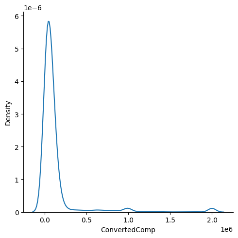

```python
# sns.distplot(df ['ConvertedComp'].dropna(),hist=False)
# df['ConvertedComp'].fillna(df['ConvertedComp'].mean(), inplace=True)
# sns.distplot (df['ConvertedComp'], hist = False)
sns.displot (df['ConvertedComp'], kind = 'kde')
```

Plot the histogram for the column `ConvertedComp`

[figure not shown]

```python
count, bin_edges = np.histogram(df['ConvertedComp'].dropna())

df['ConvertedComp'].plot(kind='hist', figsize=(8, 5), xticks=bin_edges)

plt.title('Histogram of Salary converted to annual USD salaries') # add a title to the histogram
plt.ylabel('Salary in USD') # add y-label
plt.xlabel('Number of Salary') # add x-label

plt.show()
```

Give the five number summary for the column `Age`?

```python
df['Age'].describe()
```

```
count    11111.000000
mean        30.778895
std          7.393686
min         16.000000
25%         25.000000
50%         29.000000
75%         35.000000
max         99.000000
Name: Age, dtype: float64
```

Plot a histogram of the column `Age`.

[figure not shown]

```python
count, bin_edges = np.histogram(df['Age'].dropna())

df['Age'].plot(kind='hist', figsize=(8, 5), xticks=bin_edges)

plt.title('Histogram of Age') # add a title to the histogram
plt.ylabel('Age') # add y-label
plt.xlabel('Count') # add x-label

plt.show()
```

# Outliers

Find out if outliers exist in the column `ConvertedComp` using a box plot

[figure not shown]

```python
df['ConvertedComp'].plot(kind='box', figsize=(15,7))

plt.title('Box plot of Salalry in USD')
plt.ylabel('Number of Immigrants')

plt.show()
```

Find out the Inter Quartile Range for the column `ConvertedComp`.

```python
Q1 = df['ConvertedComp'].quantile(0.25)
Q3 = df['ConvertedComp'].quantile(0.75)
IQR = Q3 - Q1
IQR
```

```
73132.0
```

```python
print("Upper Bound: {}".format(df['ConvertedComp'].max()))
print("Lower Bound: {}".format(df['ConvertedComp'].min()))
```

```
Upper Bound: 2000000.0
Lower Bound: 0.0
```

Identify how many outliers are there in the `ConvertedComp` column.

```python
((df['ConvertedComp'] < (Q1 - 1.5 * IQR)) | (df['ConvertedComp'] > (Q3 + 1.5 * IQR))).sum()
```

```
879
```

Create a new dataframe by removing the outliers from the `ConvertedComp` column.

```python
mask = (df['ConvertedComp'] < (Q1 - 1.5 * IQR)) | (df['ConvertedComp'] > (Q3 + 1.5 * IQR))
df[mask] = np.nan
df['ConvertedComp'].mean()
```

```
59883.20838915799
```

# Correlation

Find the correlation between `Age` and all other numerical columns.

```python
df.corr()
```

|  | Respondent | CompTotal | ConvertedComp | WorkWeekHrs | CodeRevHrs | Age |
| --- | --- | --- | --- | --- | --- | --- |
| Respondent | 1.000000 | -0.019364 | 0.010878 | -0.015275 | 0.002980 | 0.003950 |
| CompTotal | -0.019364 | 1.000000 | -0.063561 | 0.004975 | 0.017536 | 0.006371 |
| ConvertedComp | 0.010878 | -0.063561 | 1.000000 | 0.034351 | -0.088934 | 0.401821 |
| WorkWeekHrs | -0.015275 | 0.004975 | 0.034351 | 1.000000 | 0.031963 | 0.037452 |
| CodeRevHrs | 0.002980 | 0.017536 | -0.088934 | 0.031963 | 1.000000 | -0.017961 |
| Age | 0.003950 | 0.006371 | 0.401821 | 0.037452 | -0.017961 | 1.000000 |

- Which column has a negative correlation with "Age"?
- Which column has the highest correlation with "Age"?

## Module 4: Data Visualization

Visualizing the distribution of data

- Histograms
- Box plots

Visualizing relationship

- Scatter plots
- Bubble plots

Visualizing composition of data

- Pie charts
- Stacked charts

Visualizing comparison of data

- Line charts
- Bar charts

## Module 5: Presentation of Findings

- a paper style report
- a slideshow presentation
- maybe both

### Outline

- Cover page
  - Title of presentation
  - Name(s) of author(s)
  - Author(s)' affiliations (optional)
  - Author(s)' contact information (optional)
  - Institutional publisher name (optional)
  - Date (of publication)
- TOC
  - Sections of the report
    - Subesections
- Executive summary
  - Briefly explain the details of project
  - Considered a standalone document
  - Taken from the main points of the report. While it is acceptable to repeat information, no new information is presented
- Introduction
  - Explain the nature of the analysis
  - State the problem
  - State the questions for analysis
- Literature Review (good to have)
  - Review available relevant research on the subject matter
  - Length of this section depends on how contested the subject matter is

  In instances where the vast majority of researchers have concluded in one direction, the literature review could be brief with citations for only the most influential authors on the subject.
- Methodology
  - Explain the data sources that were used in the analysis
  - Outline the plan for the collected data

  Eg. Was the cluster or regression method used to analyze the data
  - If you have collected new data, explain the data collection exercise in some detail.
  - Refer to the literature review to bolster your choice for variables, data, and methods and how they will help you answer your research questions.
- Results
  - Present your empirical findings
  - Contains the charts and graphs that would substantiate the results and call attention to more complex/crucial findings. Starting with descriptive statistics and illustrative graphics, move toward formally testing your hypothesis (if needed)
  - Go into the detail of the data collection
    - how it was organized
    - how it was analyzed
  - Give a detailed interpretation/explanation of data to the audience and convey how it relates to the problem that was stated in the introduction

  Note: many reports in the business sector present results in a more palatable fashion by holding back the statistical details
- Discussion
  - Rely on the power of narrative to enable numbers to communicate your thesis to your readers.
  - Refer the reader to the research question and the knowledge gaps you identified earlier; highlight how your findings provide the missing piece to the puzzle
  - Engage the audience with a discussion of your implications that were drawn from your research

  Eg. say youre conducting research ofor top programming languages for college graduates. would you find they need to learn multiple languages to remain competitive in the job market or qould 1 language remain supreme  
  Of course, not all analytics return a smoking gun. At times, more frequently than I would like to acknowledge, the results provide only a partial answer to the question and that, too, with a long list of caveats.
- Conclusion
  - Generalize your specific findings and take on a rather marketing approach to promote your findings so that the reader does not remain stuck in the caveats that you have voluntarily outlined earlier
  - You might also identify future possible developments in research and applications that could result from your research.
  - reiterate the problem statend in the introduction
  - goive overall summary of the findings
  - state the outcome of the analysis and if any other stateps will be taken in the future
- Appendix
  - contains info that really didnt fit in the main body of the report but you deemed it still important enough to include
    - location where the raw data was collected
    - resources/acknowledgements/references

## Have You Done Your Job as a Writer?

As a data scientist, you are expected to do thorough analysis with the appropriate data, deploying the appropriate tools. As a writer, you are responsible for communicating your findings to the readers. Transport Policy, a leading research publication in transportation planning, offers a checklist for authors interested in publishing with the journal. The checklist is a series of questions authors are expected to consider before submitting their manuscripts to the journal. I believe the checklist is useful for budding data scientists and, therefore, I have reproduced it verbatim for their benefit.

- Have you told readers, at the outset, what they might gain by reading your paper?
- Have you made the aim of your work clear?
- Have you explained the significance of your contribution?
- Have you set your work in the appropriate context by giving sufficient background (including a complete set of relevant references) to your work?
- Have you addressed the question of practicality and usefulness?
- Have you identified future developments that might result from your work?
- Have you structured your paper in a clear and logical fashion?

### Best practices for presenting your findings

- make sure charts and graphs are not too small and are clearly labelled
- use the data only as supporting evidence
- share onlyb one point from each chart
  - begin by forming the key messages that need to be conveyed to the audience
  - and build the story around these messages
  - after building the outline go back and insert the data that/to support these findings
- eliminate data that does not support the key message

some items that seem intereesting to the analyst may not be relevant to the project. trying to explain every little detail to your audience and not recognizing irrelevant data could damage the key message